# Exploratory Data Analysis

Isaac Baca

2023-03-23

# Introduction

This project demonstrates a variety of data exploration techniques using three different data sets:

The *comics* data set which contains information on all comic characters that have been introduced by DC and Marvel is used to explore categorical data.

The *cars* data set which contains information on all new models of cars for sale in the US in a certain year is used to explore numerical data.

The *gapminder* data set which contains information on demographic data in various countries throughout the world is used to explore numerical summaries.

# Table of contents

1. Exploring Categorical Data
2. Exploring Numerical Data
3. Numerical Summaries

# Load all necessary packages.

```r
library(dplyr)
library(ggplot2)
```

# Exploring Categorical Data.

#### Import the comics data set and view the structure.

- The comics data set has information on all comic characters that have been introduced by DC and Marvel.

```r
str(comics)
```

```
## 'data.frame':    23272 obs. of  11 variables:
##  $ name        : chr  "Spider-Man (Peter Parker)" "Captain America (Steven Rogers)" "Wolverine (James \\\"Logan\\\" Howlett)" "Iron Man (Anthony \\\"Tony\\\" Stark)" ...
##  $ id          : chr  "Secret" "Public" "Public" "Public" ...
##  $ align       : chr  "Good" "Good" "Neutral" "Good" ...
##  $ eye         : chr  "Hazel Eyes" "Blue Eyes" "Blue Eyes" "Blue Eyes" ...
##  $ hair        : chr  "Brown Hair" "White Hair" "Black Hair" "Black Hair" ...
##  $ gender      : chr  "Male" "Male" "Male" "Male" ...
##  $ gsm         : chr  NA NA NA NA ...
##  $ alive       : chr  "Living Characters" "Living Characters" "Living Characters" "Living Characters" ...
##  $ appearances : int  4043 3360 3061 2961 2258 2255 2072 2017 1955 1934 ...
##  $ first_appear: chr  "Aug-62" "Mar-41" "Oct-74" "Mar-63" ...
##  $ publisher   : chr  "marvel" "marvel" "marvel" "marvel" ...
```

#### Some of the variables have a `chr` variable type. We need to change the type to `Factor`.

```r
comics[sapply(comics, is.character)] <- lapply(comics[sapply(comics, is.character)],
                                       as.factor)
str(comics)
```

```
## 'data.frame':    23272 obs. of  11 variables:
##  $ name        : Factor w/ 23272 levels "'Spinner (Earth-616)",..: 19833 3335 22769 9647 20956 2220 17576 9346 18794 10957 ...
##  $ id          : Factor w/ 4 levels "No Dual","Public",..: 3 2 2 2 1 2 2 2 2 2 ...
##  $ align       : Factor w/ 4 levels "Bad","Good","Neutral",..: 2 2 3 2 2 2 2 2 3 2 ...
##  $ eye         : Factor w/ 26 levels "Amber Eyes","Auburn Hair",..: 11 5 5 5 5 5 6 6 6 5 ...
##  $ hair        : Factor w/ 28 levels "Auburn Hair",..: 7 27 3 3 4 14 7 7 7 4 ...
##  $ gender      : Factor w/ 3 levels "Female","Male",..: 2 2 2 2 2 2 2 2 2 2 ...
##  $ gsm         : Factor w/ 6 levels "Bisexual Characters",..: NA NA NA NA NA NA NA NA NA NA ...
##  $ alive       : Factor w/ 2 levels "Deceased Characters",..: 2 2 2 2 2 2 2 2 2 2 ...
##  $ appearances : int  4043 3360 3061 2961 2258 2255 2072 2017 1955 1934 ...
##  $ first_appear: Factor w/ 1606 levels "1935, October",..: 874 1278 1513 1296 1424 1432 1432 1364 1570 1432 ...
##  $ publisher   : Factor w/ 2 levels "dc","marvel": 2 2 2 2 2 2 2 2 2 2 ...
```

`str(comics)` shows us that all `chr` variable types have now been changed to `Factor`.

#### Check levels of align.

We can see that there are four possible levels that the align variable can take.

```r
levels(comics$align)
```

```
## [1] "Bad"                "Good"               "Neutral"
## [4] "Reformed Criminals"
```

#### Check the levels of gender.

There are three possible levels that the gender variable can take.

```r
levels(comics$gender)
```

```
## [1] "Female" "Male"   "Other"
```

#### Create a 2-way contingency table of the two variables.

I will name this table `tab` for future use.

```r
tab = table(comics$align, comics$gender)
print(tab)
```

```
##
##                      Female Male Other
##   Bad                  1573 7561    32
##   Good                 2490 4809    17
##   Neutral               836 1799    17
##   Reformed Criminals      1    2     0
```

#### The contingency table from the last exercise revealed that there are some levels that have very low counts. To simplify the analysis, we will drop these levels.

- `filter(align != "Reformed Criminals")` will filter the data set for everything that is not “Reformed Criminals”.
- `droplevels()` will drop unused levels from a factor.

```r
comics <- comics %>%
  filter(align != "Reformed Criminals") %>%
  droplevels()
```

#### The `align` variable now has three levels.

```r
str(comics)
```

```
## 'data.frame':    19856 obs. of  11 variables:
##  $ name        : Factor w/ 19856 levels "'Spinner (Earth-616)",..: 16873 2786 19433 8193 17853 1833 14963 7929 15985 9317 ...
##  $ id          : Factor w/ 4 levels "No Dual","Public",..: 3 2 2 2 1 2 2 2 2 2 ...
##  $ align       : Factor w/ 3 levels "Bad","Good","Neutral": 2 2 3 2 2 2 2 2 3 2 ...
##  $ eye         : Factor w/ 26 levels "Amber Eyes","Auburn Hair",..: 11 5 5 5 5 5 6 6 6 5 ...
##  $ hair        : Factor w/ 28 levels "Auburn Hair",..: 7 27 3 3 4 14 7 7 7 4 ...
##  $ gender      : Factor w/ 3 levels "Female","Male",..: 2 2 2 2 2 2 2 2 2 2 ...
##  $ gsm         : Factor w/ 6 levels "Bisexual Characters",..: NA NA NA NA NA NA NA NA NA NA ...
##  $ alive       : Factor w/ 2 levels "Deceased Characters",..: 2 2 2 2 2 2 2 2 2 2 ...
##  $ appearances : int  4043 3360 3061 2961 2258 2255 2072 2017 1955 1934 ...
##  $ first_appear: Factor w/ 1590 levels "1936, February",..: 860 1262 1497 1280 1408 1416 1416 1348 1554 1416 ...
##  $ publisher   : Factor w/ 2 levels "dc","marvel": 2 2 2 2 2 2 2 2 2 2 ...
```

#### We can represent a contingency table graphically for ease of interpretation using a side-by-side bar chart.

- First, we create a side-by-side bar chart with `align` on the x-axis and `gender` as the fill aesthetic.
- Passing the argument `position = "dodge"` to `geom_bar()` says that you want a side-by-side (i.e. not stacked) bar chart.

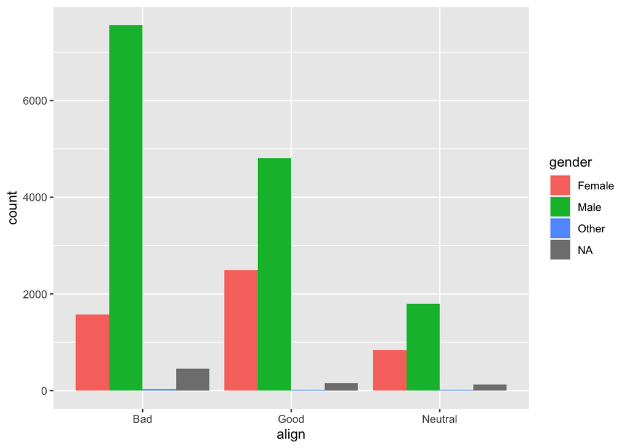

```r
ggplot(comics, aes(x = align, fill = gender)) +
  geom_bar(position = "dodge")
```

#### We can switch the x-axis and y-axis variables

- Create a side-by-side bar chart with `gender` on the x-axis and `align` as the fill aesthetic.
- `theme(axis.text.x = element_text(angle = 90))` rotates the axis lables 90 degrees to enhance readability.

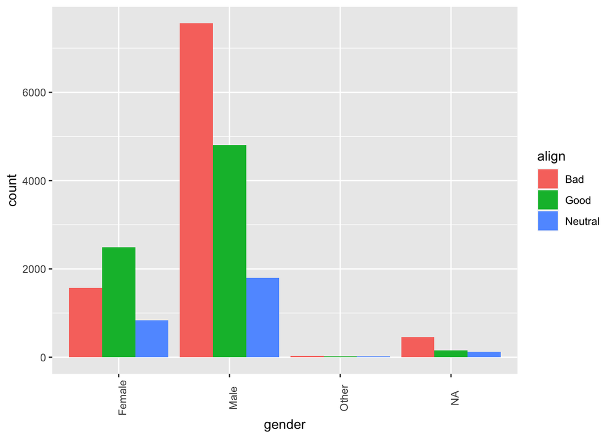

```r
ggplot(comics, aes(x = gender, fill = align)) +
  geom_bar(position = "dodge") +
  theme(axis.text.x = element_text(angle = 90))
```

#### Obtain a conditional proportion table.

- The second argument in `prop.table()` specifies whether to condition on the rows or the columns.
- `1` conditions on the rows, `2` conditions on the columns.

```r
prop.table(tab, 1)
```

```
##
##                           Female        Male       Other
##   Bad                0.171612481 0.824896356 0.003491163
##   Good               0.340349918 0.657326408 0.002323674
##   Neutral            0.315233786 0.678355958 0.006410256
##   Reformed Criminals 0.333333333 0.666666667 0.000000000
```

```r
prop.table(tab, 2)
```

```
##
##                            Female         Male        Other
##   Bad                0.3210204082 0.5335544422 0.4848484848
##   Good               0.5081632653 0.3393550208 0.2575757576
##   Neutral            0.1706122449 0.1269494037 0.2575757576
##   Reformed Criminals 0.0002040816 0.0001411333 0.0000000000
```

#### Counts vs Proportions represented graphically with bar charts.

- First, we create a stacked bar chart of `gender` *counts* with `align` on the x-axis.

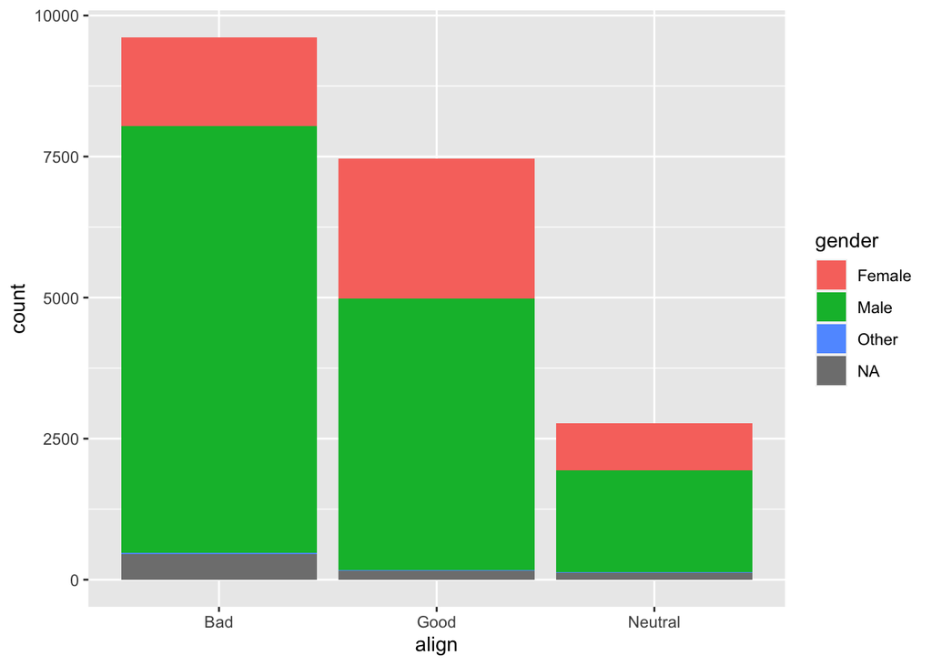

```r
ggplot(comics, aes(x = align, fill = gender)) +
  geom_bar()
```

#### The *proportions* tell a differenct story than the counts.

- Next, we create a stacked bar chart of `gender` *proportions* with `align` on the x-axis.

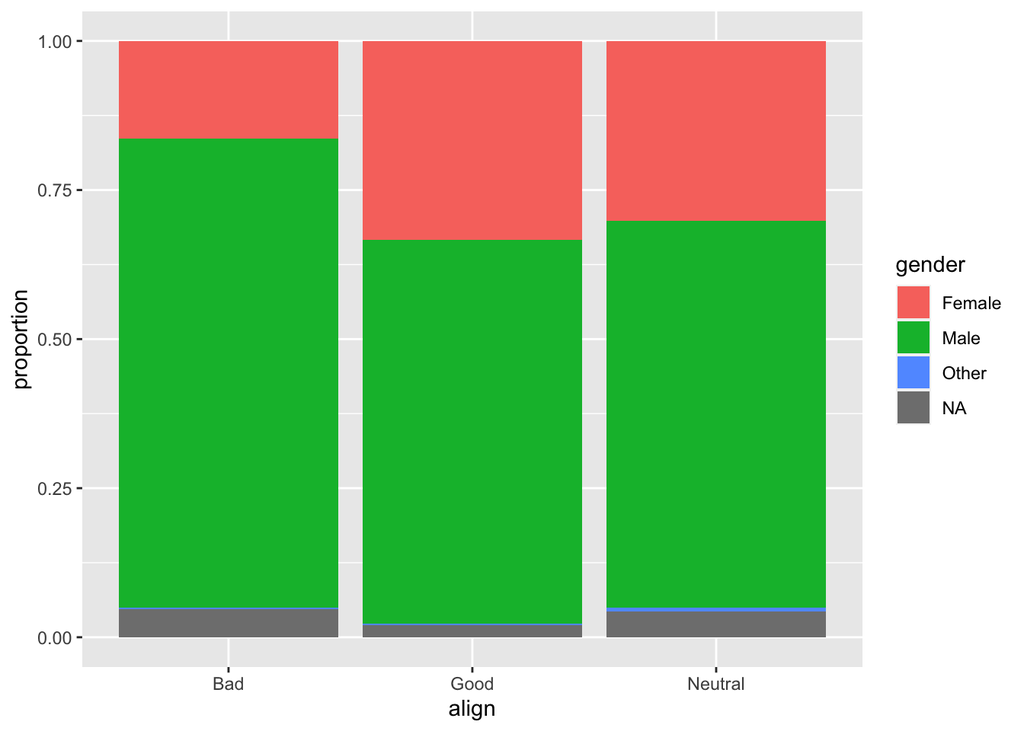

```r
ggplot(comics, aes(x = align, fill = gender)) +
  geom_bar(position = "fill") +
  ylab("proportion")
```

#### View the distribution of alignment of all superheroes.

- First, we change the order of the levels in `align` to improve the interpretability of the plot by passing a vector to the second argument of `factor()`.
- Then, we construct a bar chart that represents the distribution of alignment of all superheroes.

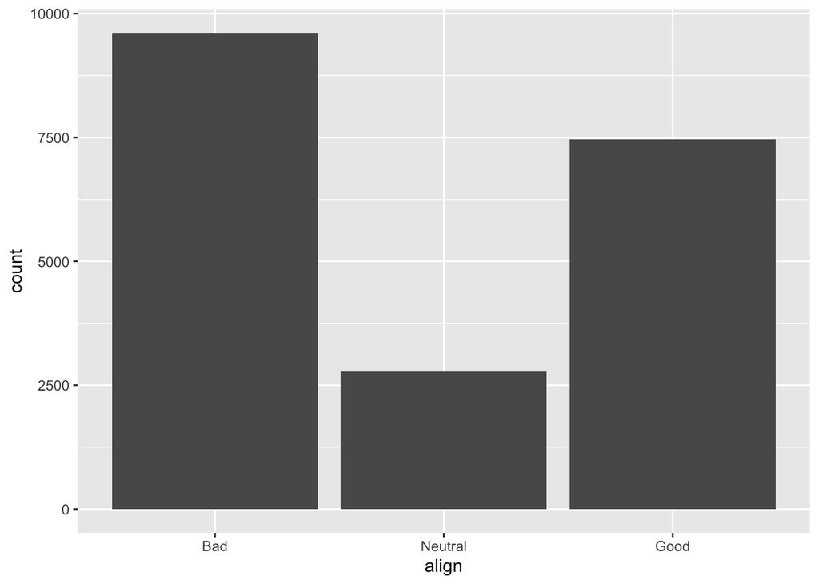

```r
comics$align <- factor(comics$align, levels = c("Bad", "Neutral", "Good"))

ggplot(comics, aes(x = align)) +
  geom_bar()
```

#### Conditional distributions.

- We can further break down the distribution of alignment based on gender.
- We can use `facet_wrap(~ gender)` to facet by gender.

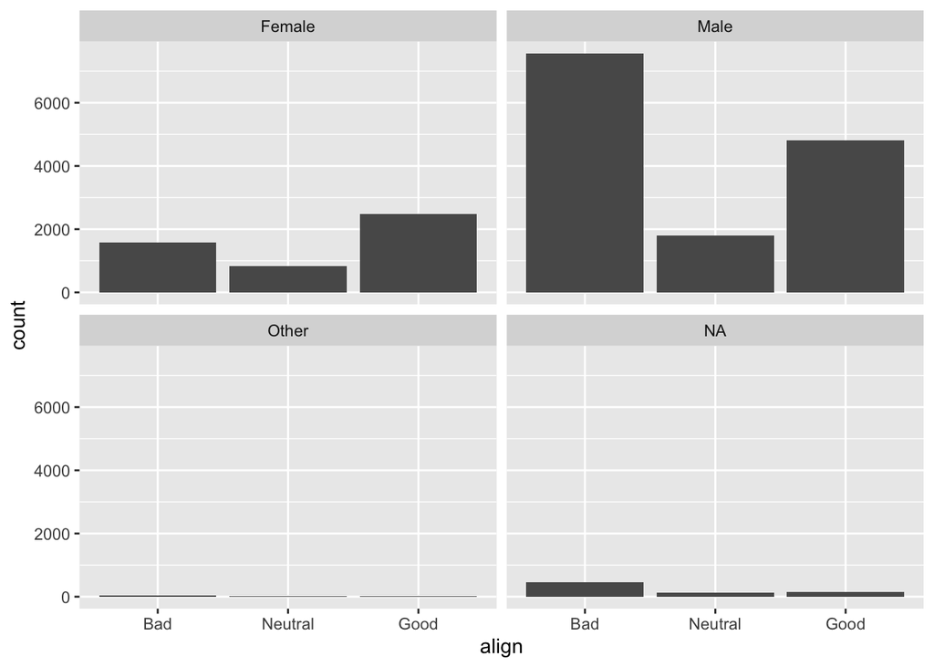

```r
ggplot(comics, aes(x = align)) +
  geom_bar() +
  facet_wrap(~ gender)
```

# Exploring Numerical Data.

- The `cars` data set records characteristics on all of the new models of cars for sale in the US in a certain year.

```r
cars = read.csv("/Volumes/Vandy Main/Data Camp/R/Exploratory Data Analysis/cars04.csv")
str(cars)
```

```
## 'data.frame':    428 obs. of  19 variables:
##  $ name       : chr  "Chevrolet Aveo 4dr" "Chevrolet Aveo LS 4dr hatch" "Chevrolet Cavalier 2dr" "Chevrolet Cavalier 4dr" ...
##  $ sports_car : logi  FALSE FALSE FALSE FALSE FALSE FALSE ...
##  $ suv        : logi  FALSE FALSE FALSE FALSE FALSE FALSE ...
##  $ wagon      : logi  FALSE FALSE FALSE FALSE FALSE FALSE ...
##  $ minivan    : logi  FALSE FALSE FALSE FALSE FALSE FALSE ...
##  $ pickup     : logi  FALSE FALSE FALSE FALSE FALSE FALSE ...
##  $ all_wheel  : logi  FALSE FALSE FALSE FALSE FALSE FALSE ...
##  $ rear_wheel : logi  FALSE FALSE FALSE FALSE FALSE FALSE ...
##  $ msrp       : int  11690 12585 14610 14810 16385 13670 15040 13270 13730 15460 ...
##  $ dealer_cost: int  10965 11802 13697 13884 15357 12849 14086 12482 12906 14496 ...
##  $ eng_size   : num  1.6 1.6 2.2 2.2 2.2 2 2 2 2 2 ...
##  $ ncyl       : int  4 4 4 4 4 4 4 4 4 4 ...
##  $ horsepwr   : int  103 103 140 140 140 132 132 130 110 130 ...
##  $ city_mpg   : int  28 28 26 26 26 29 29 26 27 26 ...
##  $ hwy_mpg    : int  34 34 37 37 37 36 36 33 36 33 ...
##  $ weight     : int  2370 2348 2617 2676 2617 2581 2626 2612 2606 2606 ...
##  $ wheel_base : int  98 98 104 104 104 105 105 103 103 103 ...
##  $ length     : int  167 153 183 183 183 174 174 168 168 168 ...
##  $ width      : int  66 66 69 68 69 67 67 67 67 67 ...
```

#### Plot a histogram of `city_mpg` faceted by `suv`, a logical variable indicating whether the car is an SUV or not.

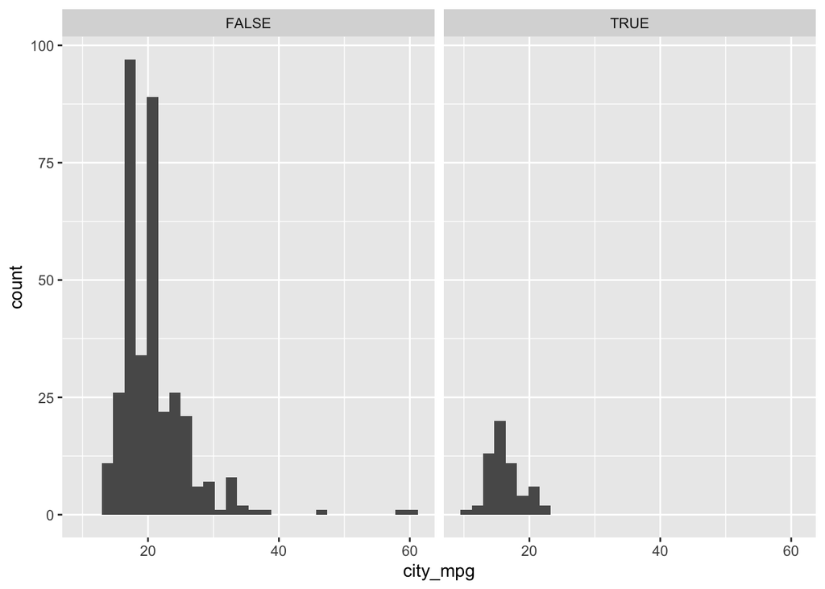

```r
ggplot(cars, aes(x = city_mpg)) +
  geom_histogram() +
  facet_wrap(~ suv)
```

#### Explore the relationship between the milage of a car and the size of the engine.

- First, we filter the data set for cars with 4, 6, or 8 cylinders and save the result as `common_cyl`.

```r
common_cyl <- filter(cars, ncyl == 4 | ncyl == 6 | ncyl == 8)
```

#### Create side-by-side box plots of `city_mpg` separated out by `ncyl`.

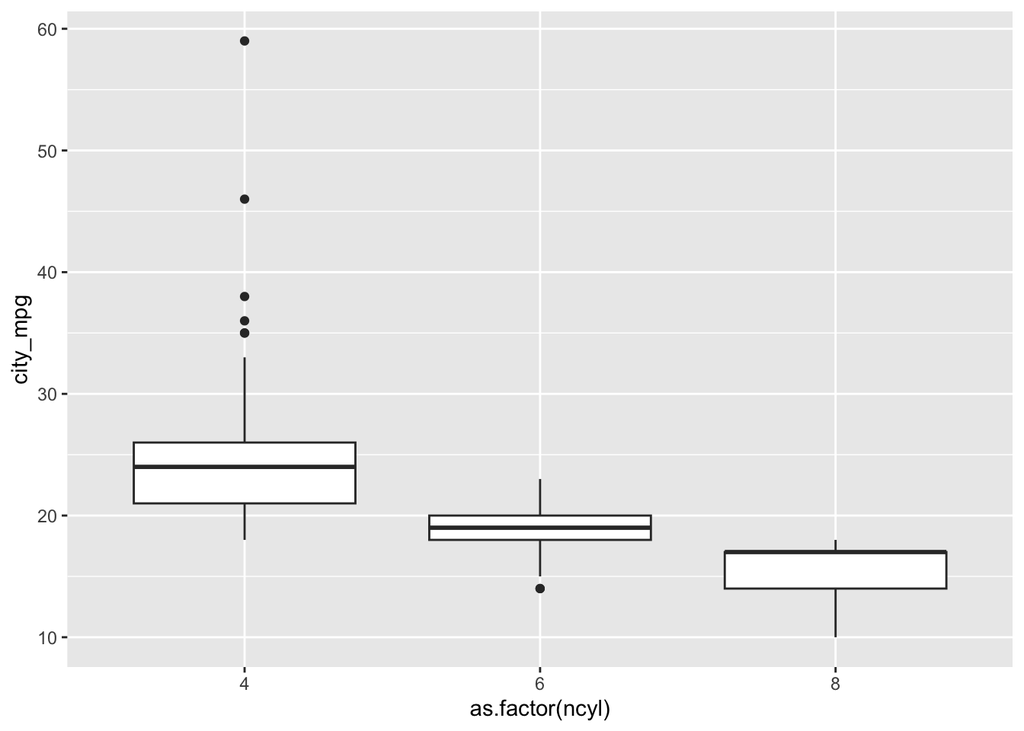

```r
ggplot(common_cyl, aes(x = as.factor(ncyl), y = city_mpg)) +
  geom_boxplot()
```

#### Create overlaid density plots of `city_mpg` colored by `ncyl`.

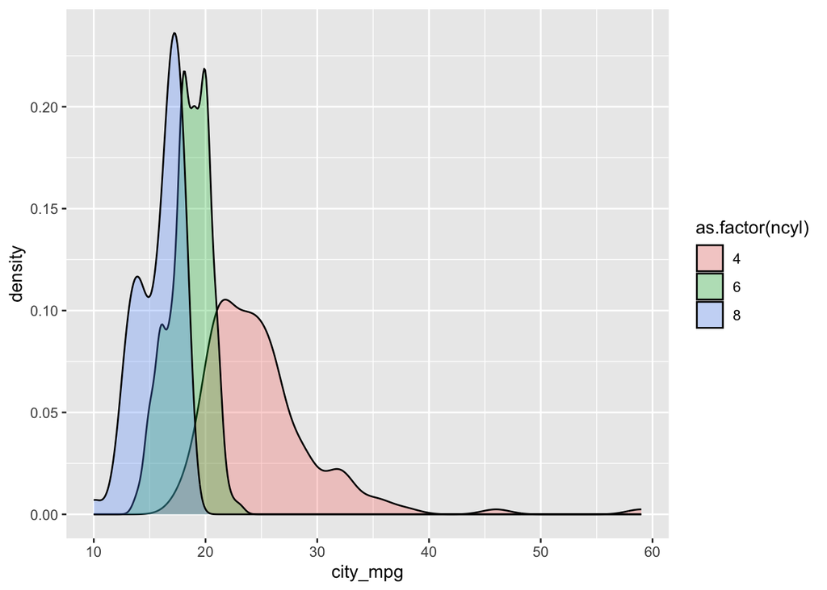

```r
ggplot(common_cyl, aes(x= city_mpg, fill = as.factor(ncyl))) +
  geom_density(alpha = .3)
```

#### Create a histogram of the distribution of `horsepwr` across all cars.

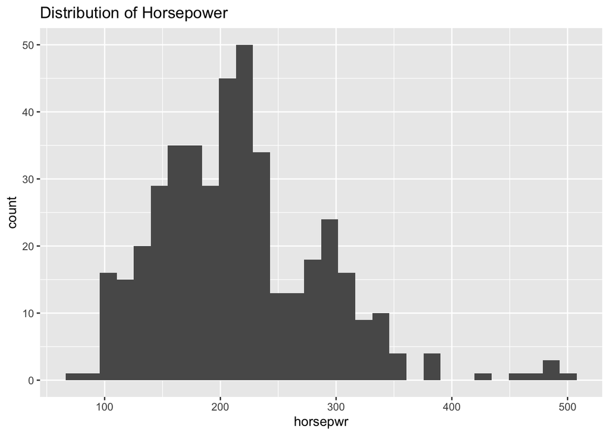

```r
cars %>%
  ggplot(aes(x = horsepwr)) +
  geom_histogram() +
  ggtitle("Distribution of Horsepower")
```

#### Create a second histogram of the distribution of `horsepwr`, but only for those cars that have an `msrp` less than $25,000.

- Set the `xlim()` and `ylim()` to match the previous histogram.

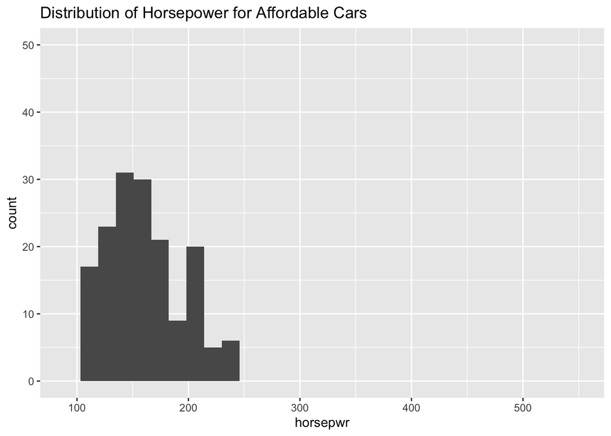

```r
cars %>%
  filter(msrp < 25000) %>%
  ggplot(aes(x = horsepwr)) +
  geom_histogram() +
  ylim(c(0, 50)) +
  xlim(c(90, 550)) +
  ggtitle("Distribution of Horsepower for Affordable Cars")
```

#### View how the histogram changes as the binwidth changes.

- First, we set `binwidth = 3`.
- Next, we set `binwidth = 30`.
- Finally, we set `binwidth = 60`.

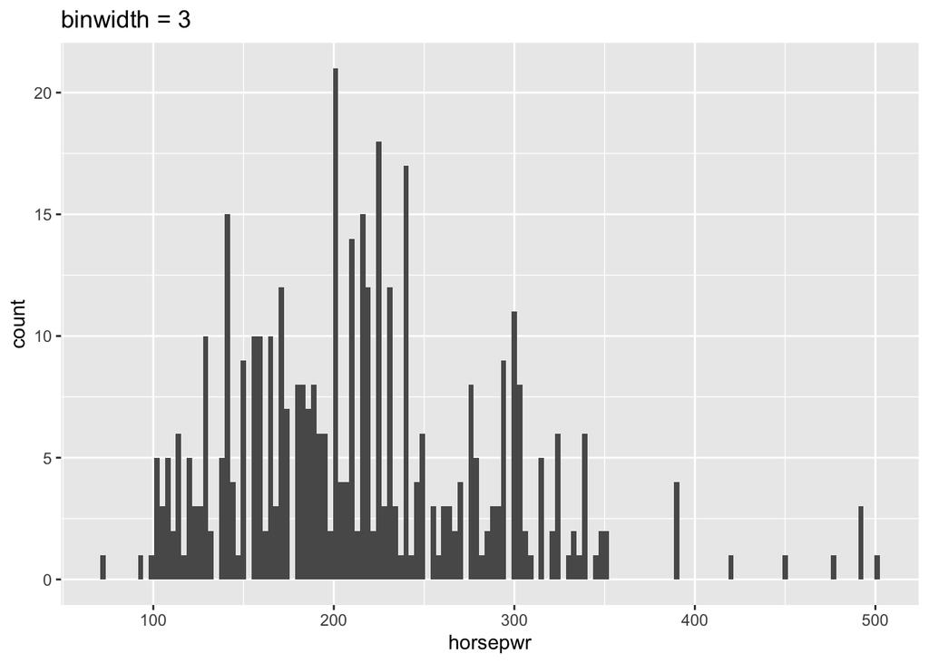

```r
cars %>%
  ggplot(aes(horsepwr)) +
  geom_histogram(binwidth = 3) +
  ggtitle("binwidth = 3")
```

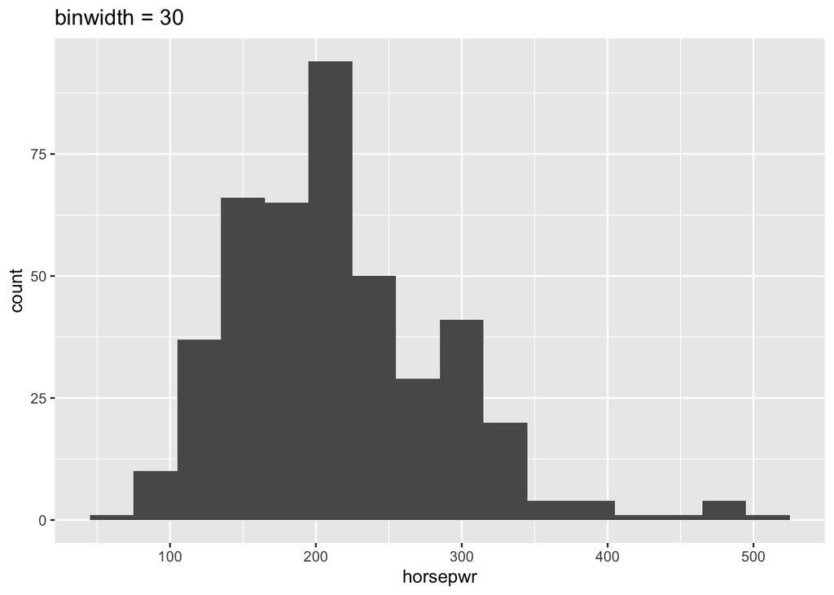

```r
cars %>%
  ggplot(aes(horsepwr)) +
  geom_histogram(binwidth = 30) +
  ggtitle("binwidth = 30")
```

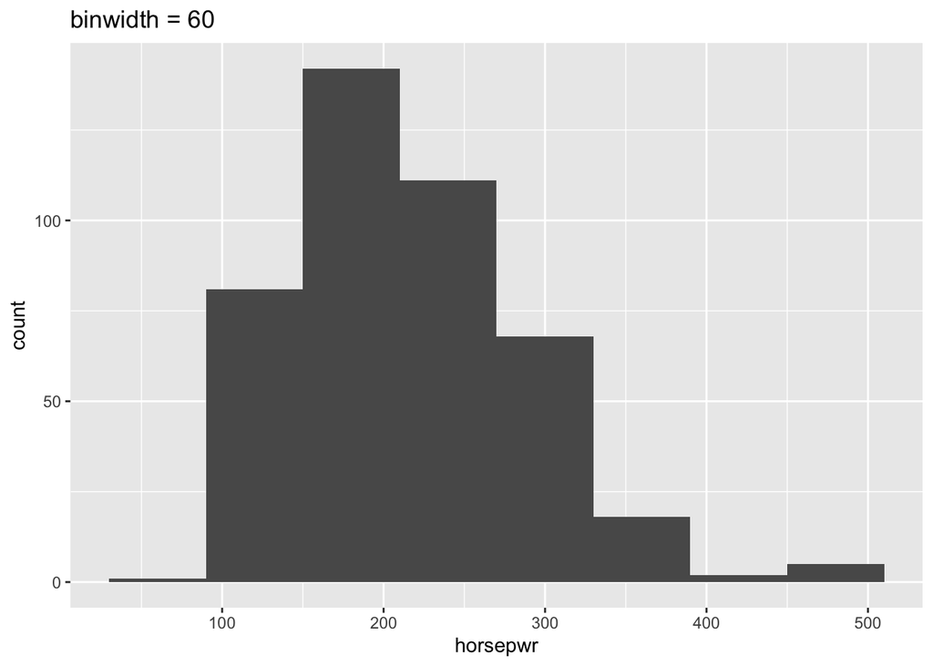

```r
cars %>%
  ggplot(aes(horsepwr)) +
  geom_histogram(binwidth = 60) +
  ggtitle("binwidth = 60")
```

#### In addition to indicating the center and spread of a distribution, a box plot provides a graphical means to detect outliers.

- I construct a box plot of `msrp` (manufacturer’s suggested retail price) to detect if there are unusually expensive or cheap cars.

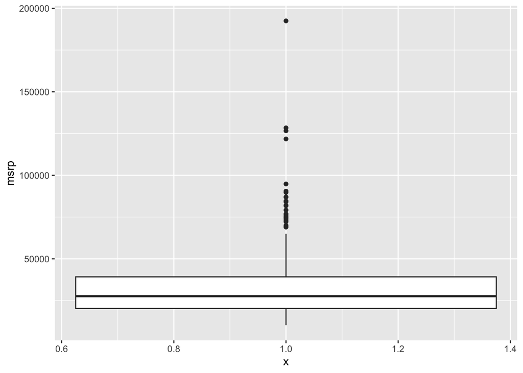

```r
cars %>%
  ggplot(aes(x = 1, y = msrp)) +
  geom_boxplot()
```

#### I exclude the largest 3-5 outliers by filtering the rows to retain cars less than $100,000.

- This new data set will be called `cars_no_out`.

```r
cars_no_out <- cars %>%
  filter(msrp < 100000)
```

#### I construct a similar box plot of `msrp` using this reduced dataset.

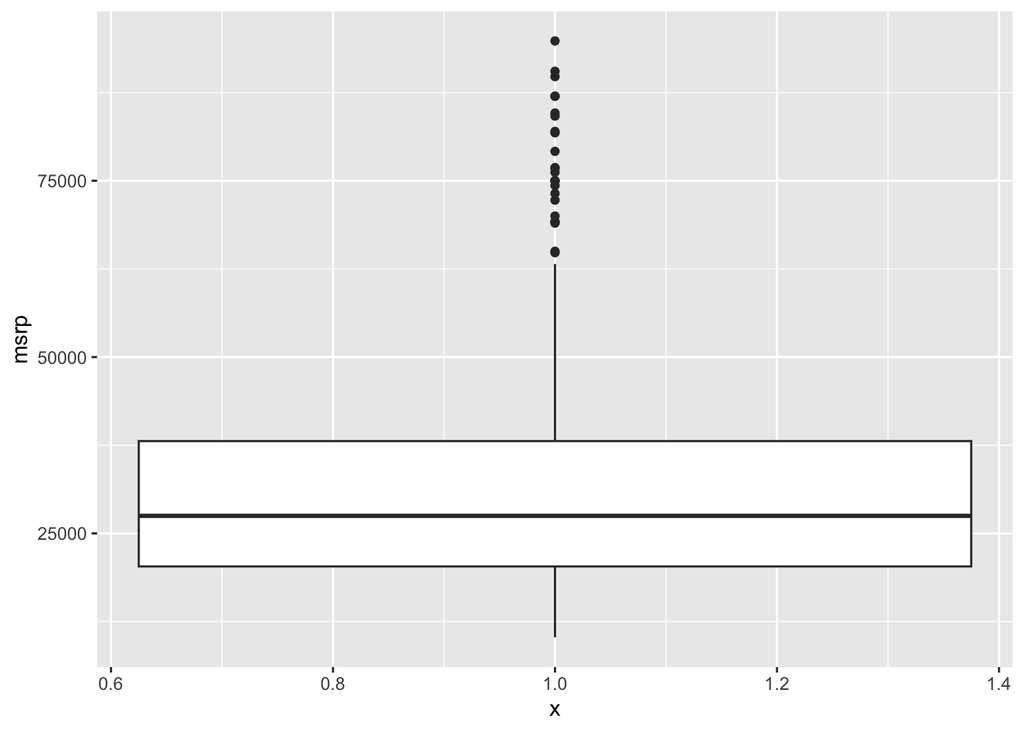

```r
cars_no_out %>%
  ggplot(aes(x = 1, y = msrp)) +
  geom_boxplot()
```

#### Both density plots and box plots display the central tendency and spread of the data, but the box plot is more robust to outliers.

- `city_mpg` can be represented using either a density plot or a box plot.
- As these plots demonstrate, `city_mpg` contains many outliers. Therefore, a box plot would be the better choice here.

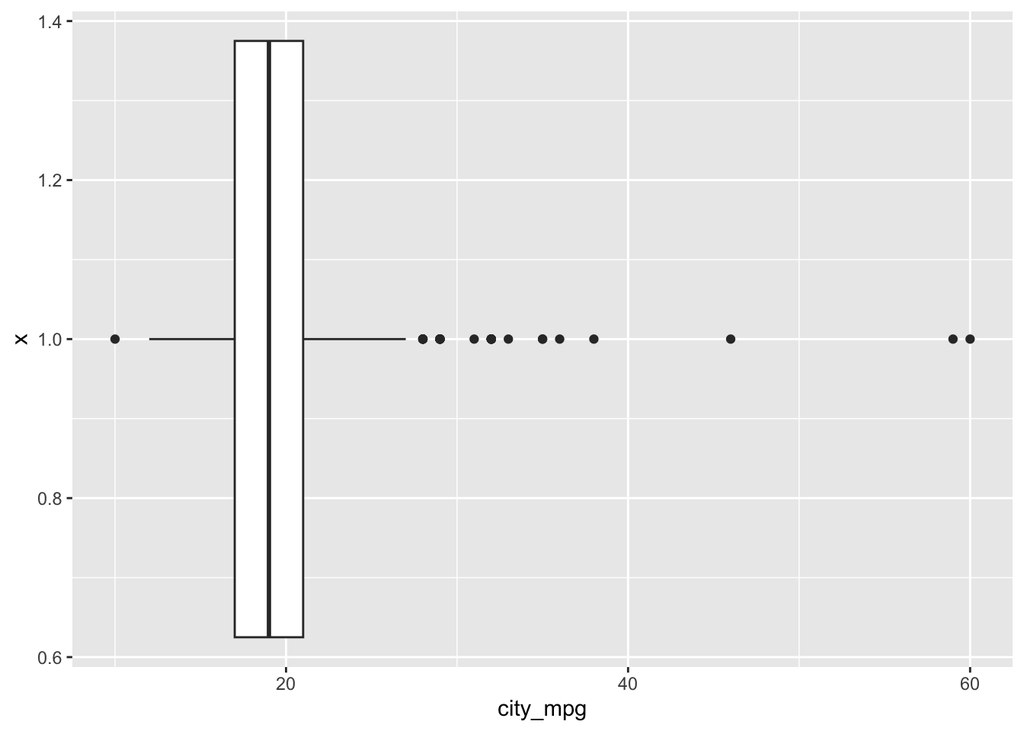

```r
cars %>%
  ggplot(aes(x = 1, y = city_mpg)) +
  geom_boxplot() +
  coord_flip()
```

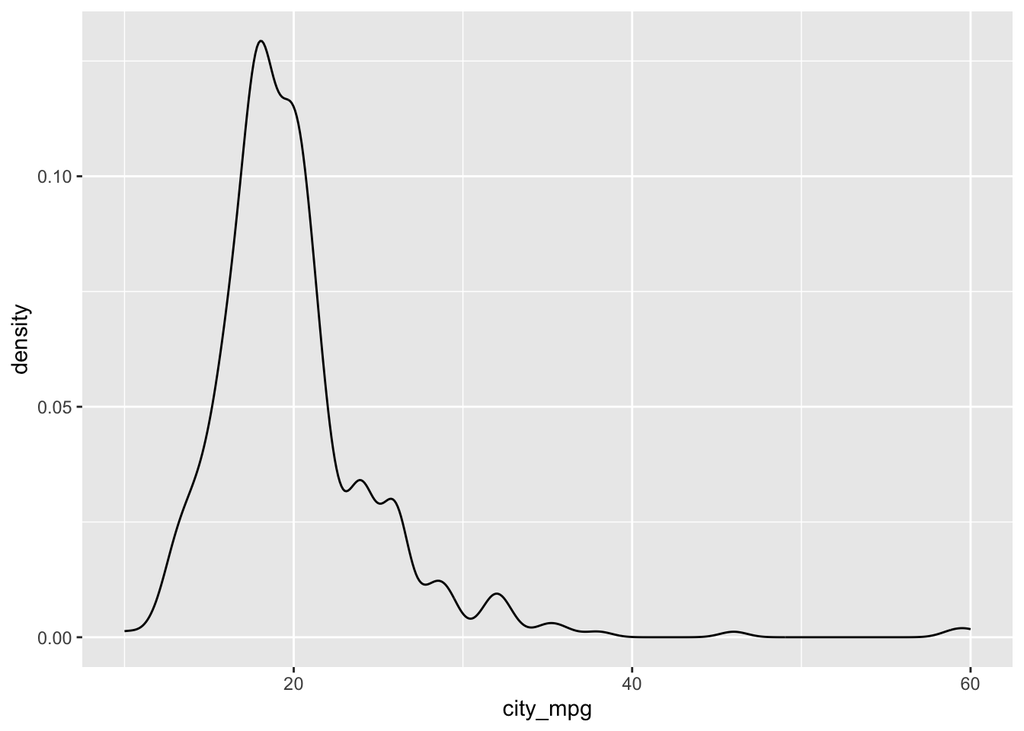

```r
cars %>%
  ggplot(aes(x = city_mpg)) +
  geom_density()
```

#### Similarly, `width` can be represented using either a density plot or a box plot.

- In this case, a density plot would be the better choice.

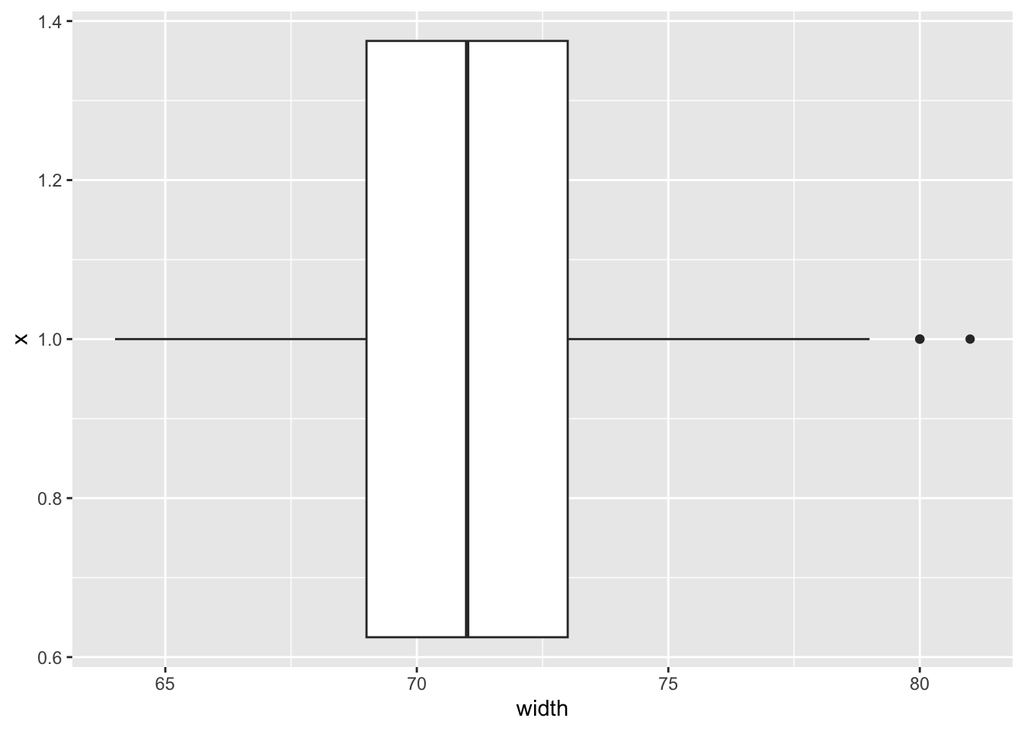

```r
cars %>%
  ggplot(aes(x = 1, y = width)) +
  geom_boxplot() +
  coord_flip()
```

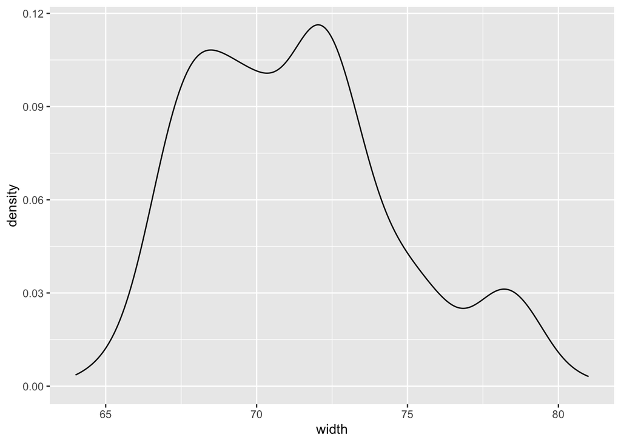

```r
cars %>%
  ggplot(aes(x = width)) +
  geom_density()
```

#### We can look at several conditional distributions at the same time by using `facet_grid`.

- `common_cyl` contains only cars with 4, 6, or 8 cylinders.
- I use `common_cyl` to create a histogram of `hwy_mpg`.
- I grid-facet the plot rowwise by `ncyl` and columnwise by `suv`.

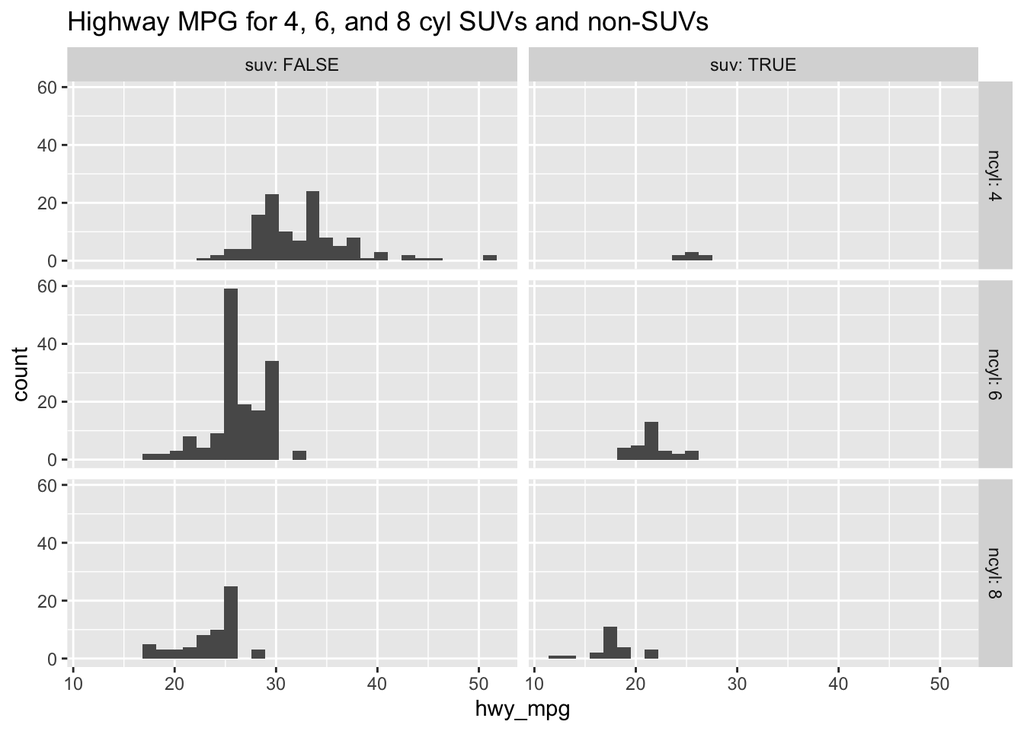

```r
common_cyl %>%
  ggplot(aes(x = hwy_mpg)) +
  geom_histogram() +
  facet_grid(ncyl ~ suv, labeller = label_both) +
  ggtitle("Highway MPG for 4, 6, and 8 cyl SUVs and non-SUVs")
```

# Numerical Summaries.

#### Import the gapminder data set and view the structure.

- The `gapminder` data set tracks demographic data in various countries throughout the world over time.

```r
gapminder = read.csv("/Volumes/Vandy Main/Data Camp/R/Exploratory Data Analysis/gapminder.csv")
str(gapminder)
```

```
## 'data.frame':    1704 obs. of  6 variables:
##  $ country  : chr  "Afghanistan" "Afghanistan" "Afghanistan" "Afghanistan" ...
##  $ continent: chr  "Asia" "Asia" "Asia" "Asia" ...
##  $ year     : int  1952 1957 1962 1967 1972 1977 1982 1987 1992 1997 ...
##  $ lifeExp  : num  28.8 30.3 32 34 36.1 ...
##  $ pop      : int  8425333 9240934 10267083 11537966 13079460 14880372 12881816 13867957 16317921 22227415 ...
##  $ gdpPercap: num  779 821 853 836 740 ...
```

#### Some of the variables have a `chr` variable type. We need to change the type to `Factor`.

- I check the structure of the data set again to make sure all `chr` variables were changed to `Factor`.

```r
gapminder[sapply(gapminder, is.character)] <- lapply(gapminder[sapply(gapminder, is.character)],
                                               as.factor)
str(gapminder)
```

```
## 'data.frame':    1704 obs. of  6 variables:
##  $ country  : Factor w/ 142 levels "Afghanistan",..: 1 1 1 1 1 1 1 1 1 1 ...
##  $ continent: Factor w/ 5 levels "Africa","Americas",..: 3 3 3 3 3 3 3 3 3 3 ...
##  $ year     : int  1952 1957 1962 1967 1972 1977 1982 1987 1992 1997 ...
##  $ lifeExp  : num  28.8 30.3 32 34 36.1 ...
##  $ pop      : int  8425333 9240934 10267083 11537966 13079460 14880372 12881816 13867957 16317921 22227415 ...
##  $ gdpPercap: num  779 821 853 836 740 ...
```

#### I start by creating a dataset called `gap2007` that contains only data from the year 2007.

```r
gap2007 <- filter(gapminder, year == 2007)
```

#### Using `gap2007`, I calculate the mean and median life expectancy for each continent.

```r
gap2007 %>%
  group_by(continent) %>%
  summarize(mean(lifeExp), median(lifeExp))
```

```
## # A tibble: 5 × 3
##   continent `mean(lifeExp)` `median(lifeExp)`
##   <fct>               <dbl>             <dbl>
## 1 Africa               54.8              52.9
## 2 Americas             73.6              72.9
## 3 Asia                 70.7              72.4
## 4 Europe               77.6              78.6
## 5 Oceania              80.7              80.7
```

#### I confirm the trends that I see in the medians by generating side-by-side box plots of life expectancy for each continent.

- This also enables us to view the spread of life expectancy for each continent, as well as any potential outliers.

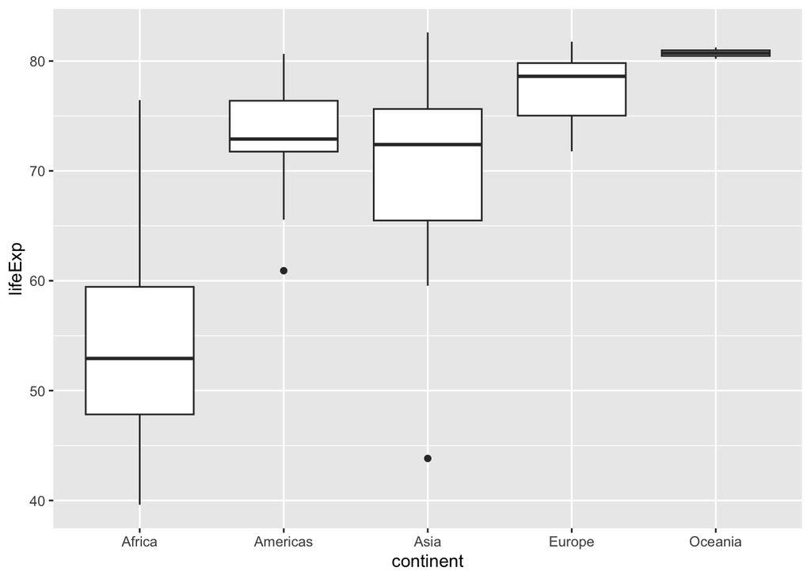

```r
gap2007 %>%
  ggplot(aes(x = continent, y = lifeExp)) +
  geom_boxplot()
```

#### If its unclear whether the distribution of the data is symmetric or skewed, it’s a good idea to consider a robust measure like **IQR** in addition to the usual measures of **variance** or **standard deviation**.

- For each continent in `gap2007`, I summarize the life expectancies using `sd()`, the `IQR()`, and the count of countries, `n()`.

```r
gap2007 %>%
  group_by(continent) %>%
  summarize(sd(lifeExp), IQR(lifeExp), n())
```

```
## # A tibble: 5 × 4
##   continent `sd(lifeExp)` `IQR(lifeExp)` `n()`
##   <fct>             <dbl>          <dbl> <int>
## 1 Africa            9.63          11.6      52
## 2 Americas          4.44           4.63     25
## 3 Asia              7.96          10.2      33
## 4 Europe            2.98           4.78     30
## 5 Oceania           0.729          0.516     2
```

#### I compare the spread of these distributions by constructing overlaid density plots of life expectancy broken down by continent.

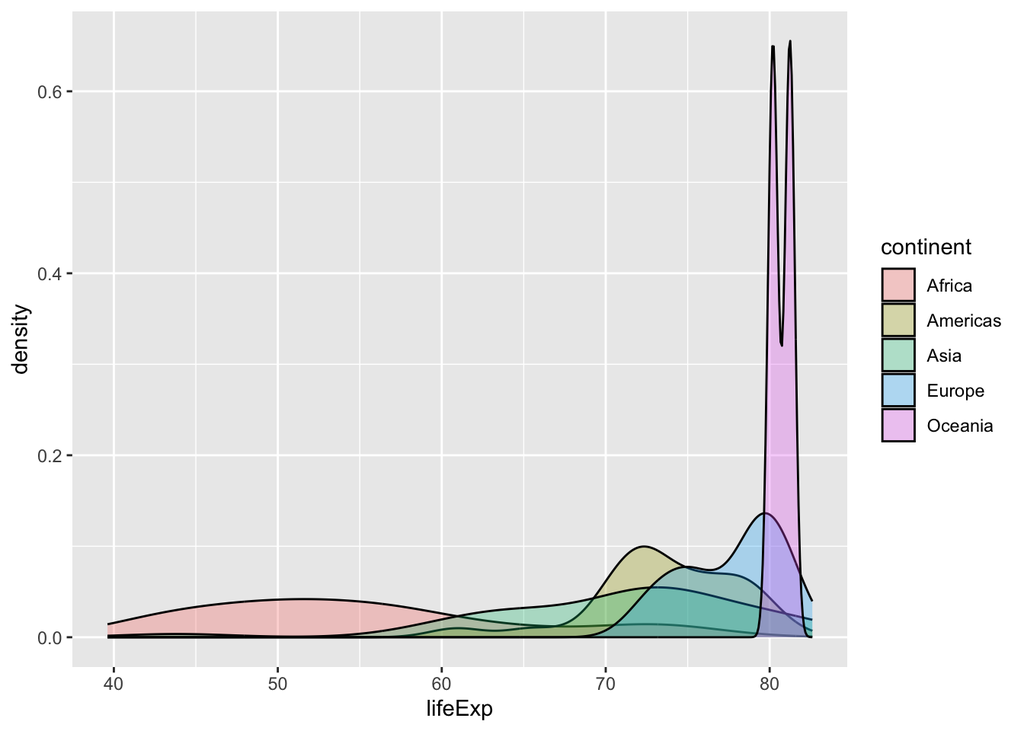

```r
gap2007 %>%
  ggplot(aes(x = lifeExp, fill = continent)) +
  geom_density(alpha = 0.3)
```

#### I want to determine the most appropriate measures of center and spread for the distribution of life expectancy in the Americas.

- To view the spread, I create a density plot for life expectancy in the Americas.

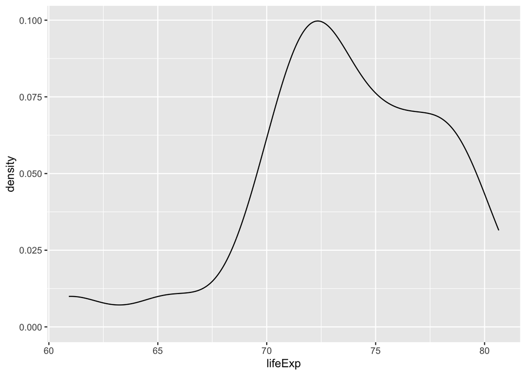

```r
gap2007 %>%
  filter(continent == "Americas") %>%
  ggplot(aes(x = lifeExp)) +
  geom_density()
```

- We can see that the distribution is farily normal.
- Therefore, I use `mean()` and `sd()` as measures of center and spread.

```r
gap2007 %>%
  filter(continent == "Americas") %>%
  summarize(mean(lifeExp), sd(lifeExp))
```

```
##   mean(lifeExp) sd(lifeExp)
## 1      73.60812    4.440948
```

#### I want to determine the appropriate measures of center and spread for the distribution of country *populations* across the entire `gap2007` data set.

- To view the spread, I create a density plot for country level populations.

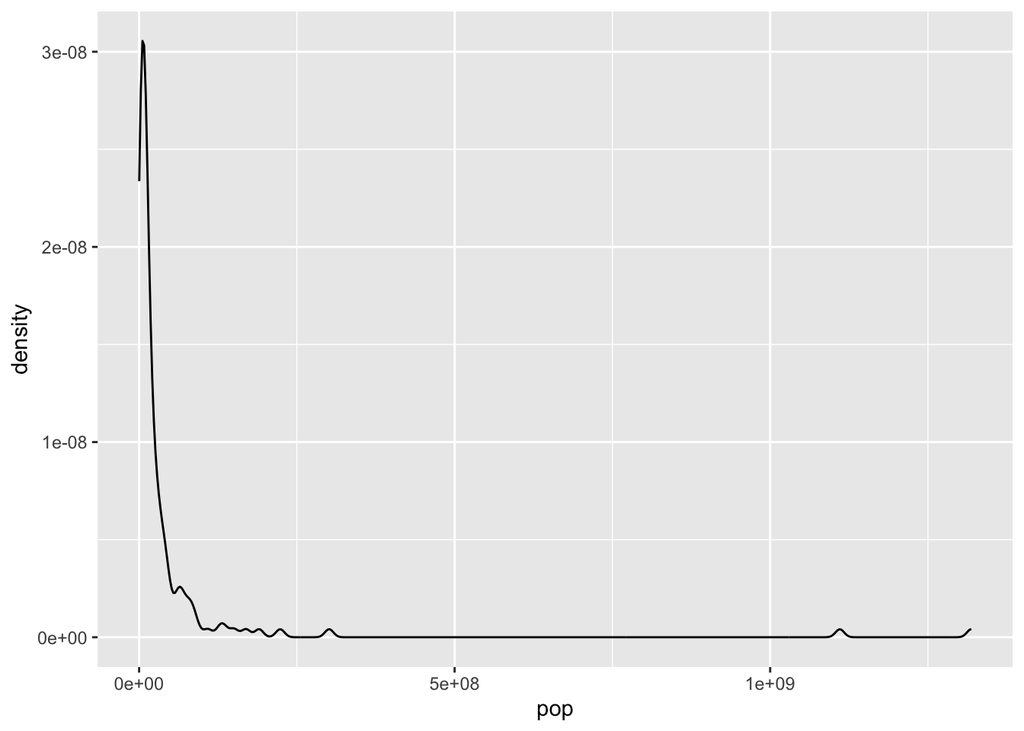

```r
gap2007 %>%
  ggplot(aes(x = pop)) +
  geom_density()
```

- We can see that the density plot has a strong skew.
- Therefore, I use `median()` and `IQR()` as measures of center and spread.

```r
gap2007 %>%
  summarize(median(pop), IQR(pop))
```

```
##   median(pop) IQR(pop)
## 1    10517531 26702008
```

#### Highly skewed distributions can make it very difficult to learn anything from a visualization. Transformations can be helpful in revealing the more subtle structure.

- As the last plot demonstrated, the population variable is highly skewed.

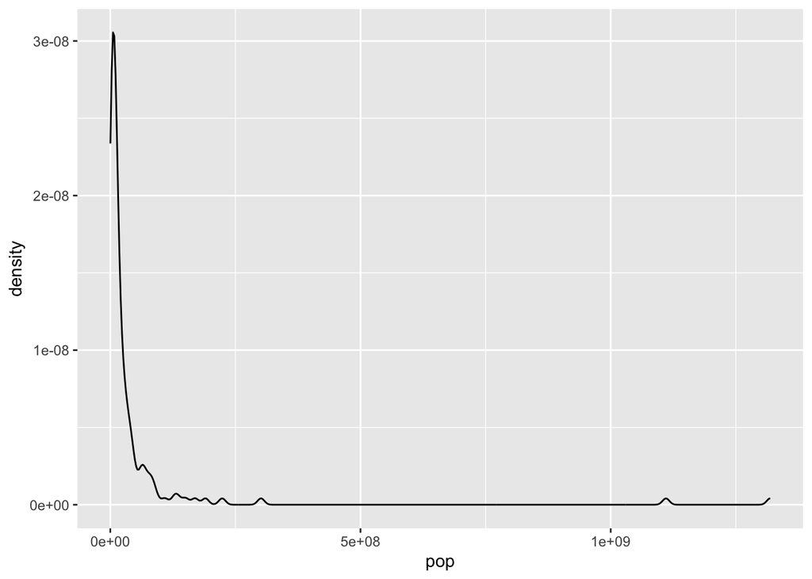

```r
gap2007 %>%
  ggplot(aes(x = pop)) +
  geom_density()
```

#### The population variable can be transformed using the natural logarithm funciton, `log()`.

- I take the transformed variable and add it to the `gap2007` data frame using `mutate(log_pop = log(pop))`.

```r
gap2007 <- gap2007 %>%
  mutate(log_pop = log(pop))
str(gap2007)
```

```
## 'data.frame':    142 obs. of  7 variables:
##  $ country  : Factor w/ 142 levels "Afghanistan",..: 1 2 3 4 5 6 7 8 9 10 ...
##  $ continent: Factor w/ 5 levels "Africa","Americas",..: 3 4 1 1 2 5 4 3 3 4 ...
##  $ year     : int  2007 2007 2007 2007 2007 2007 2007 2007 2007 2007 ...
##  $ lifeExp  : num  43.8 76.4 72.3 42.7 75.3 ...
##  $ pop      : int  31889923 3600523 33333216 12420476 40301927 20434176 8199783 708573 150448339 10392226 ...
##  $ gdpPercap: num  975 5937 6223 4797 12779 ...
##  $ log_pop  : num  17.3 15.1 17.3 16.3 17.5 ...
```

#### I create a density plot of the transformed population variable.

- Using the transformed population variable makes for a much better visualization.

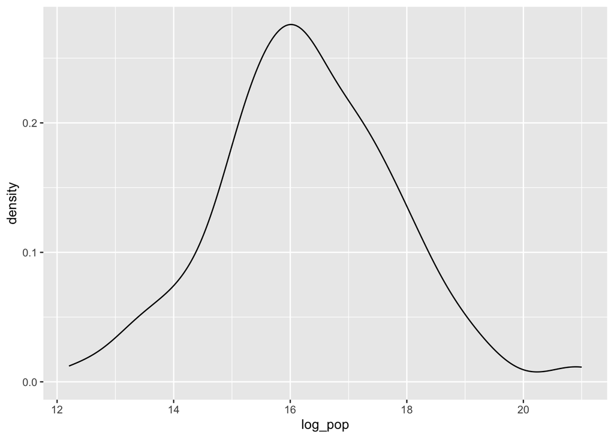

```r
gap2007 %>%
  ggplot(aes(x = log_pop)) +
  geom_density()
```

#### The box plot below visualizes life expenctancies of countries in Asia.

- There is one clear outlier: a country with a notably low life expectancy.

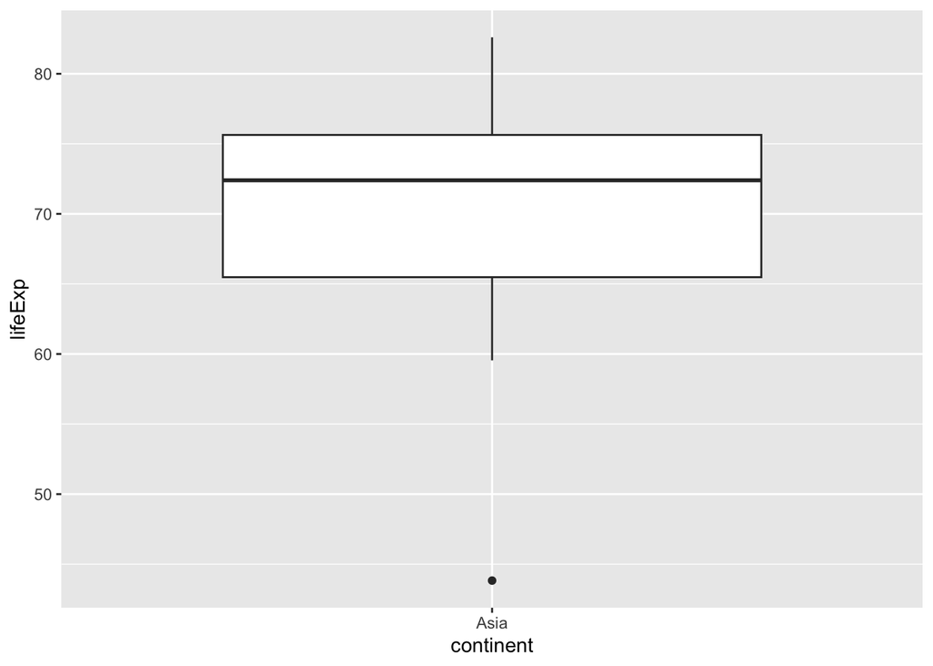

```r
gap2007 %>%
  filter(continent == "Asia") %>%
  ggplot(aes(x = continent, y = lifeExp)) +
  geom_boxplot()
```

#### I use `min(gap2007_Asia$lifeExp)` to find the outlier.

```r
gap2007_Asia = gap2007 %>%
  filter(continent == "Asia")

  min(gap2007_Asia$lifeExp)
```

```
## [1] 43.828
```

#### I find the observation where life expectancy is 43.828.

```r
gap2007_Asia %>%
    filter(lifeExp == 43.828)
```

```
##       country continent year lifeExp      pop gdpPercap log_pop
## 1 Afghanistan      Asia 2007  43.828 31889923  974.5803 17.2778
```

#### I create a new variable called `is_outlier` that is `TRUE` for countries with life expectancy less than 50.

- This variable is only true for Afghanistan.

```r
gap_asia <- gap2007 %>%
 filter(continent == "Asia") %>%
 mutate(is_outlier = lifeExp < 50)
head(gap_asia)
```

```
##            country continent year lifeExp        pop  gdpPercap  log_pop
## 1      Afghanistan      Asia 2007  43.828   31889923   974.5803 17.27780
## 2          Bahrain      Asia 2007  75.635     708573 29796.0483 13.47101
## 3       Bangladesh      Asia 2007  64.062  150448339  1391.2538 18.82913
## 4         Cambodia      Asia 2007  59.723   14131858  1713.7787 16.46394
## 5            China      Asia 2007  72.961 1318683096  4959.1149 20.99990
## 6 Hong Kong, China      Asia 2007  82.208    6980412 39724.9787 15.75862
##   is_outlier
## 1       TRUE
## 2      FALSE
## 3      FALSE
## 4      FALSE
## 5      FALSE
## 6      FALSE
```

#### I filter `gap_asia` to remove all outliers, then create another box plot of the remaining life expectancies.

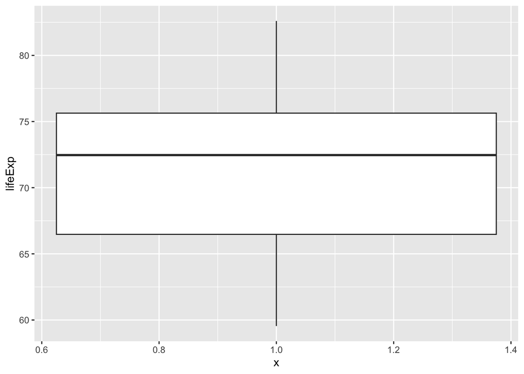

```r
gap_asia %>%
 filter(!is_outlier) %>%
 ggplot(aes(x = 1, y = lifeExp)) +
 geom_boxplot()
```